# The Big Three

*Author: Joey Hastings*

Men’s professional tennis has existed for over a century. **Wimbledon**, one of the most prestigious tennis tournaments, had its inaugural season in 1877[^1]. The two organizations that govern men’s tennis today are the **Association of Tennis Professionals** (ATP)[^2] and the **International Tennis Federation** (ITF)[^3].

The ATP holds the ATP Tour which is comprised of four different lower level tournaments: ATP Masters 1000, ATP 500, ATP 250, and the ATP Cup[^4]. The ITF organizes and sanctions the four **grand slams majors** (tournaments recognized as the most important each year): the **Australian Open**, **French Open**, **Wimbledon**, and the **US Open**. Winning just one of these four tournaments is one of the most envied achievements by professional tennis players.

Despite the tough competition at this level, three male players have emerged over the past two decades in men’s singles due to their incredible success. The **Big Three** is a nickname given to **Novak Djokovic**, **Rafael Nadal**, and **Roger Federer** for their never-before-seen dominance in the scene.

So, how dominant could they be? Let’s take a look at the number of major wins different players have won since 1968:

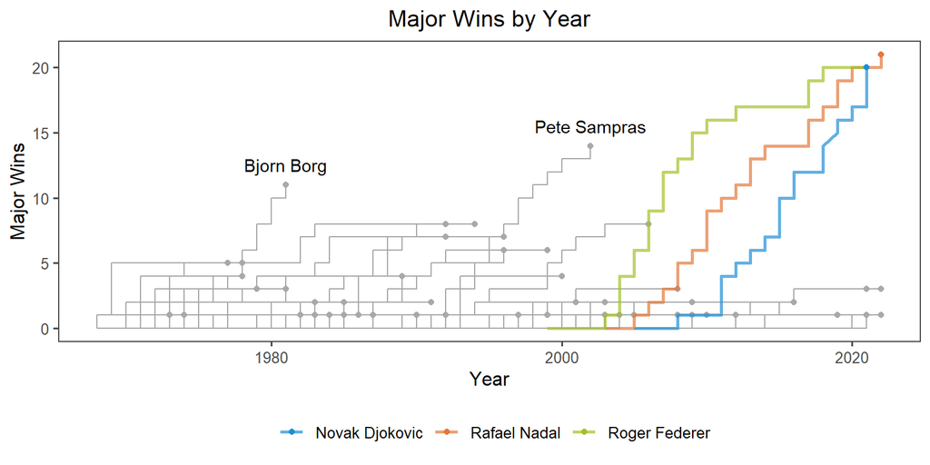

Each of the big three have at least **20** major wins! The only other two players with double-digit wins are **Pete Sampras** and **Bjorn Borg**, winning 14 and 11, respectively.

What about their longevity? How well have they been able to continue their success throughout their career?

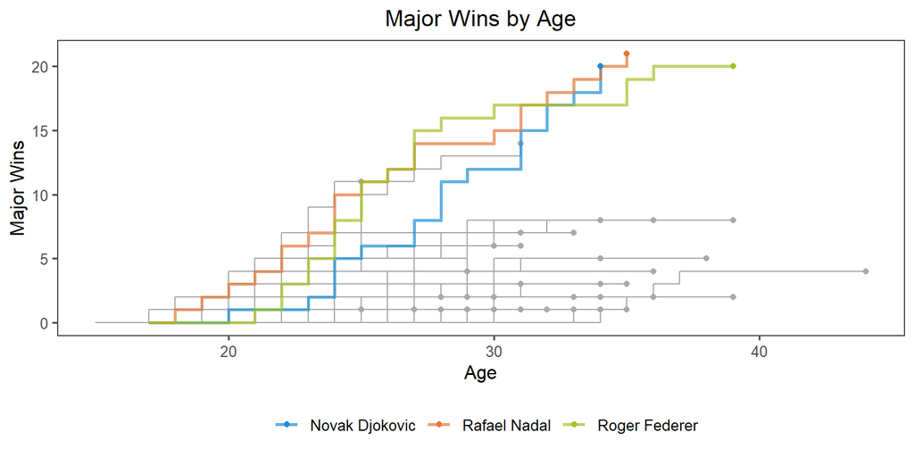

The big three have continued their success well into their mid-to-late 30’s!

To give another perspective on how dominant the big three have been, let’s take a look at all the major winners since 2003 (the year **Roger Federer** won his first major):

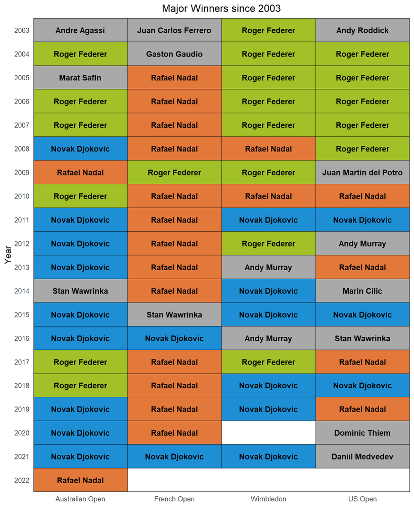

The trio has won **61** of the last **76** major tournaments (just over an 80% win rate). Note that **Wimbledon** in 2020 was cancelled due to concerns regarding the COVID-19 pandemic[^5].

How are the major wins split between each member of the big three? Do they each perform the same at each tournament?

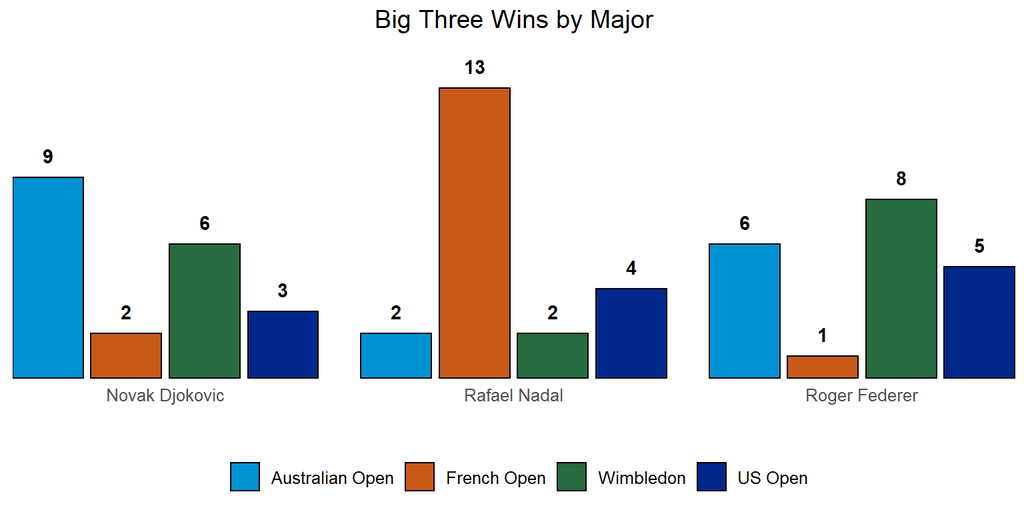

We can see that there is quite a difference in majors won by each player. It is clear that **Rafael Nadal** is the most dominant at the **French Open**, having won **13** of them. **Novak Djokovic** has won the most **Australian Open** titles with **9**, and **Roger Federer** has won the most **Wimbledon** and **US Open** titles, at **8** and **5**, respectively.

What about the competition between the big three? The table below indicates the player’s win/loss ratio against the opponent in the corresponding column across all ATP and ITF matches:

|  | Novak Djokovic | Rafael Nadal | Roger Federer |
| --- | --- | --- | --- |
| Novak Djokovic |  | 30-28 | 28-23 |
| Rafael Nadal | 28-30 |  | 24-17 |
| Roger Federer | 23-28 | 17-24 |  |

**Novak Djokovic** is the only member to have a win/loss ratio above **1.0** against each of the other two, having won **30** of **58** matches against **Rafael Nadal** and **28** of **51** matches against **Roger Federer**. The competition between these three has been fierce!

How long will the **big three** dominance reign? With **Rafael Nadal** having won the most recent **Australian Open**, it bumped his major wins to **21** placing him in the lead. If you were to ask me, it doesn’t look like their dominance will be ending any time soon.

[^1]: https://web.archive.org/web/20101221222928/http://www.wimbledon.org/en_GB/about/history/1877.html
[^2]: https://www.atptour.com/en/corporate/about
[^3]: https://www.itftennis.com/en/itf-tours/grand-slam-tournaments/
[^4]: https://www.atptour.com/en/tournaments
[^5]: https://www.cnn.com/2020/04/01/tennis/wimbledon-canceled-coronavirus-2020-spt-intl/index.html